# Programming and Data Analysis

> Modeling with Scikit-Learn

Yao-Jen Kuo yaojenkuo@ntu.edu.tw from [DATAINPOINT](https://www.datainpoint.com/)

## About Scikit-Learn

## What is Scikit-Learn

> Scikit-learn is an open source machine learning library that supports supervised and unsupervised learning. It also provides various tools for model fitting, data preprocessing, model selection, model evaluation, and many other utilities.

Source：https://scikit-learn.org

## Import Scikit-Learn with `from` and `import`

Most of the time we use specific classes or functions from Scikit-Learn. So we use `from sklearn.SUBMODULE import FUNCTION/CLASS` rather than `import sklearn`.

Source: https://scikit-learn.org/stable/getting_started.html

```python
import sklearn # use `from sklearn.SUBMODULE import FUNCTION/CLASS` instead
```

## If `sklearn` is not installed, we will encounter a `ModuleNotFoundError`

```
Traceback (most recent call last):
  File "<stdin>", line 1, in <module>
ModuleNotFoundError: No module named 'sklearn'
```

## Use `conda install` at Terminal to install `scikit-learn`

```
(ENVNAME) conda install scikit-learn
```

## Check version and its installation file path

- `__version__` attribute
- `__file__` attribute

```python
print(sklearn.__version__)
print(sklearn.__file__)
```

```
1.3.0
/Users/kuoyaojen/miniconda3/envs/datascience/lib/python3.11/site-packages/sklearn/__init__.py
```

## Why Scikit-Learn

- Simple, consistent and well-designed API. Users can easily switch to different models once being familiar with the fundamentals of its principle.
- Detailed and complete official documentation.
- Well-maintained.

## Scikit-Learn API design principle

1. Consistency.
2. Inspection.
3. Limited object hierarchy.
4. Composition.
5. Sensible defaults.

## Data representation in Scikit-Learn: features matrix and target array

- Features matrix with a shape of `(m, n)`: $X$
- Target array with a shape of `(m,)`: $y$

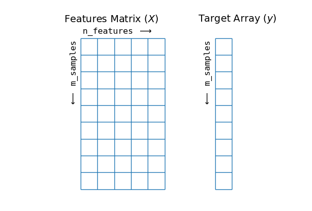

```python
# Source：<https://jakevdp.github.io/PythonDataScienceHandbook>
plot_X_y()
```

## Estimator for pre-processing

## Estimator is the most important API in Scikit-Learn

1. **Estimator for pre-processing.**
2. Estimator for prediction.

## Standard steps using estimator for pre-processing

1. Preparing features matrix $X$ or target array $y$
2. Creating an estimator object.
3. Calling `estimator.fit_transform()` on features matrix or target array.

## Example datasets

- [House Prices](https://github.com/datainpoint/classroom-programming-and-data-analysis/blob/main/data/house_prices_train.csv)
- [Titanic](https://github.com/datainpoint/classroom-programming-and-data-analysis/blob/main/data/titanic_train.csv)

```python
import pandas as pd

house_prices = pd.read_csv("https://raw.githubusercontent.com/datainpoint/classroom-programming-and-data-analysis/main/data/house_prices_train.csv")
titanic = pd.read_csv("https://raw.githubusercontent.com/datainpoint/classroom-programming-and-data-analysis/main/data/titanic_train.csv")
```

## An estimator `PolynomialFeatures`

Generate a new feature matrix consisting of all polynomial combinations of the features with degree less than or equal to the specified degree.

```python
from sklearn.preprocessing import PolynomialFeatures

X = house_prices["GrLivArea"].values.reshape(-1, 1)
polynomial_features = PolynomialFeatures()
X_transformed = polynomial_features.fit_transform(X)
print(X_transformed[:5])
```

```
[[1.000000e+00 1.710000e+03 2.924100e+06]
 [1.000000e+00 1.262000e+03 1.592644e+06]
 [1.000000e+00 1.786000e+03 3.189796e+06]
 [1.000000e+00 1.717000e+03 2.948089e+06]
 [1.000000e+00 2.198000e+03 4.831204e+06]]
```

## An estimator `StandardScaler`

Standardize features by removing the mean and scaling to unit variance.

\begin{equation} z = \frac{x - \mu}{\sigma} \end{equation}

```python
from sklearn.preprocessing import StandardScaler

X = titanic["Fare"].values.reshape(-1, 1)
standard_scaler = StandardScaler()
X_transformed = standard_scaler.fit_transform(X)
print(X_transformed[:5])
```

```
[[-0.50244517]
 [ 0.78684529]
 [-0.48885426]
 [ 0.42073024]
 [-0.48633742]]
```

## Estimator for prediction

## Estimator is the most important API in Scikit-Learn

1. Estimator for pre-processing.
2. **Estimator for prediction.**

## Standard steps using estimator for prediction

1. Preparing features matrix $X$ and target array $y$
2. Calling `train_test_split()` function to split features matrix and target array.
3. Creating an estimator object.
4. Calling `estimator.fit()` on training data.
5. Calling `estimator.predict()` on test features matrix.
6. Comparing the difference between $\hat{y}$ and $y$

## An estimator `LinearRegression`

```python
from sklearn.model_selection import train_test_split
from sklearn.linear_model import LinearRegression

X = house_prices["GrLivArea"].values.reshape(-1, 1)
y = house_prices["SalePrice"].values
X_train, X_test, y_train, y_test = train_test_split(X, y, random_state=42)
linear_regression = LinearRegression()
linear_regression.fit(X_train, y_train)
y_hat = linear_regression.predict(X_test)
m = y_test.size
mean_squared_error = ((y_test - y_hat)**2).sum()/m
print(mean_squared_error)
```

```
3118447791.9869404
```

## An estimator `LogisticRegression`

```python
from sklearn.linear_model import LogisticRegression

X = titanic[["Fare", "SibSp", "Parch"]].values
y = titanic["Survived"].values
X_train, X_test, y_train, y_test = train_test_split(X, y, random_state=42)
logistic_regression = LogisticRegression()
logistic_regression.fit(X_train, y_train)
y_hat = logistic_regression.predict(X_test)
number_of_misclassification = (y_test != y_hat).sum()
print(number_of_misclassification)
```

```
72
```

## Scikit-Learn API design principle

1. **Consistency.**
2. **Inspection.**
3. Limited object hierarchy.
4. Composition.
5. **Sensible defaults.**

## Scikit-Learn API design principle: Consistency

- Every estimator for pre-processing has a `fit_transform()` method.
- Every estimator for prediction has a `fit()` and a `predict()` method.

## Scikit-Learn API design principle: Sensible defaults

Every estimator can be created with default parameters.

## Scikit-Learn API design principle: Inspection

```python
print(polynomial_features.degree)
print(standard_scaler.mean_)
print(standard_scaler.scale_)
print(linear_regression.intercept_)
print(linear_regression.coef_)
print(logistic_regression.intercept_)
print(logistic_regression.coef_)
```

```
2
[32.20420797]
[49.66553444]
24812.580398812395
[102.46754356]
[-0.91152283]
[[ 0.01628413 -0.25345491  0.16100239]]
```